# Análisis de los supuestos

Luis Fernando Apáez Álvarez

14/11/2021

Linealidad, homocedasticidad y normalidad

Supuesto de la covarianza cero

Otro caso

# Covarianza cero

Comenzamos por cargar los datos

```r
library(latex2exp)
Datos = read.csv("ejemplo4.csv")
```

y después realizamos el scatterplot inicial

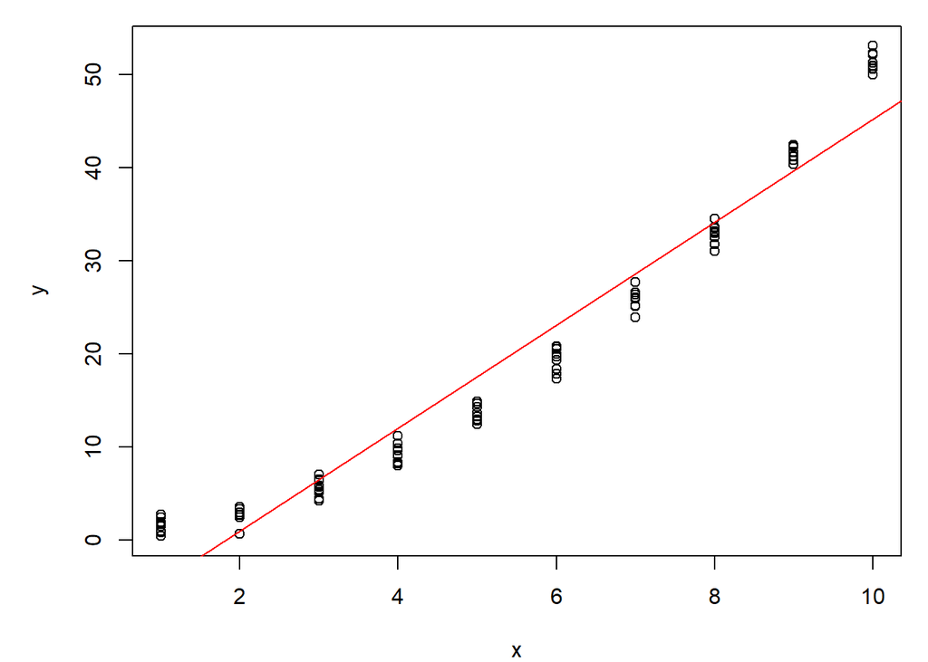

```r
# Ajuste del modelo
fit=lm(y~x, data=Datos)

# Gráfica
par(mfrow=c(1,1))
par(mar=c(4, 5, 1, 1))
plot(Datos$x, Datos$y, xlab = TeX("$x$"), ylab=TeX("$y$"))

abline(fit, col="red")
```

## Linealidad, homocedasticidad y normalidad

Dado que este ejemplo ya fue trabajado, para recordar que los estos supuestos se cumplen cuando transformamos a la variable $x$ bastará con ver las gráficas que `R` trae por defecto. Primero

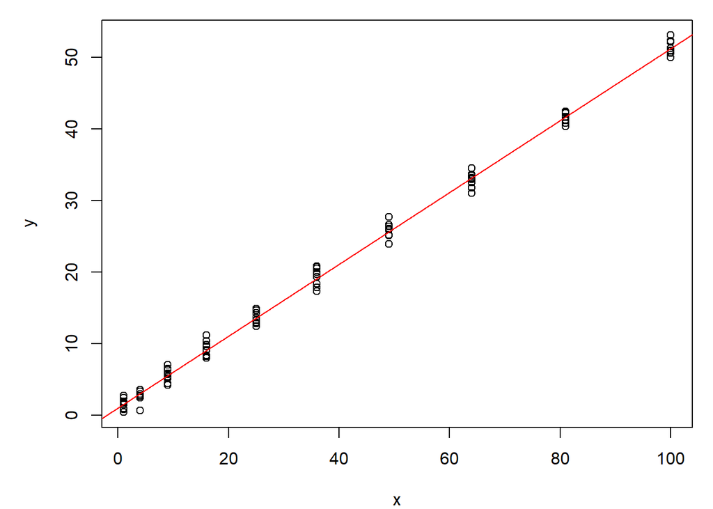

```r
#Se transforma X a X^2 para lograr linealidad
Datos$Xprima=Datos$x^2

# Se realiza el ajuste con los datos transformados
fit2=lm(y~Xprima, data=Datos)

# Gráfica
par(mfrow=c(1,1))
par(mar=c(4, 5, 1, 1))
plot(Datos$Xprima, Datos$y, xlab = TeX("$x$"), ylab=TeX("$y$"))

abline(fit2, col="red")
```

Y finalmente

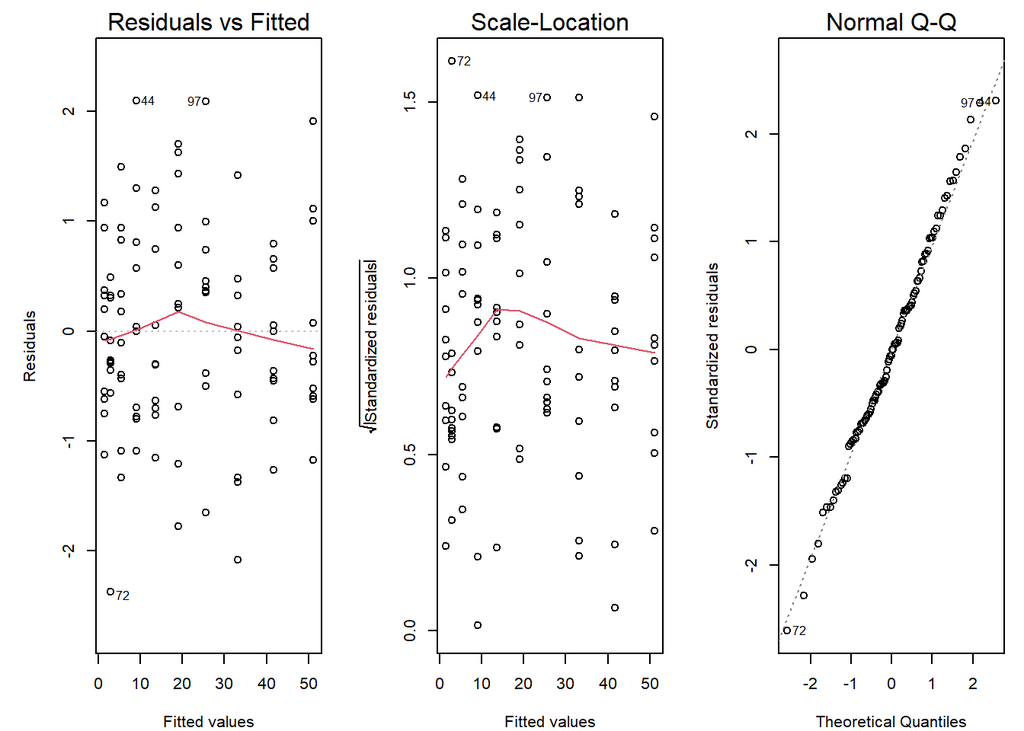

```r
#gráficas para linealidad-homocedasticidad-normalidad

par(mar=c(4, 5, 2, 1))
par(mfrow=c(1,3))
plot(fit2, 1)
plot(fit2, 3)
plot(fit2, 2)
```

## Supuesto de la covarianza cero

- Comenzamos por ver el gráfico sobre el índice de los datos

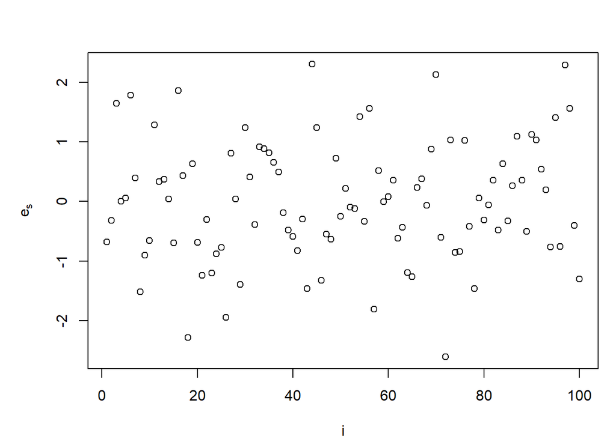

  ```r
  #gráfica sobre el índice de los datos

  # Librería para calcular los errores
  library(broom)
  Datosfit2=augment(fit2)

  # Gráfica
  par(mar=c(4, 5, 3, 1))
  par(mfrow=c(1,1))
  plot(1:length(Datosfit2$.std.resid), Datosfit2$.std.resid, xlab = TeX("$i$"), ylab=TeX("$e_s$")   )
  ```

  del cual no puede observarse algún patrón evidente.
- Seguimos con el autocorrelograma

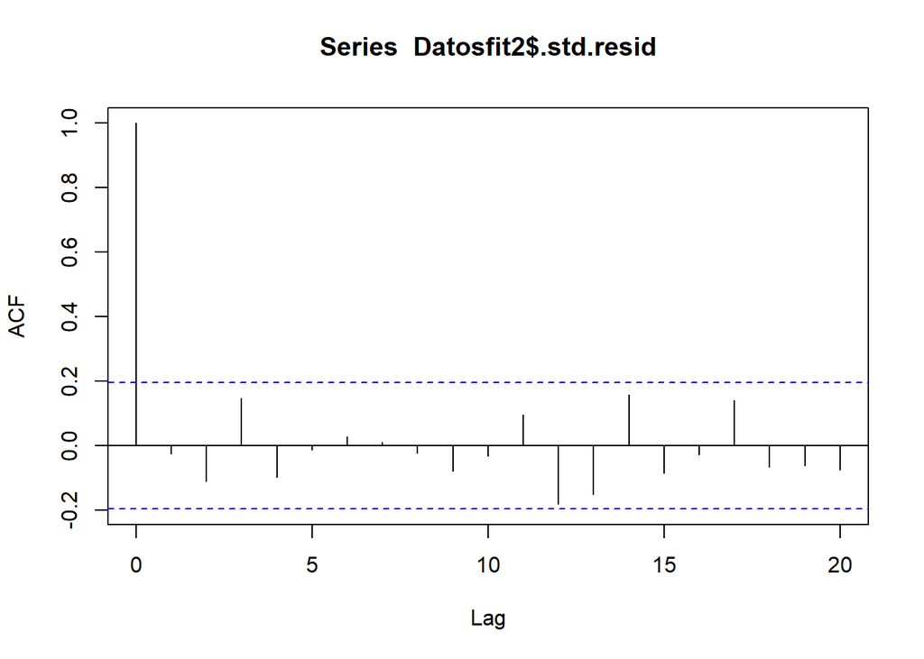

  ```r
  #autocorrelograma de los errores

  acf(Datosfit2$.std.resid)
  ```

  donde tampoco vemos algún valor que salga de los valores de las rectas horizontales punteadas. Así, hasta el momento no hemos encontrado evidencia en contra del supuesto de la covarianza cero.
- Pasamos a realizar las pruebas de rachas

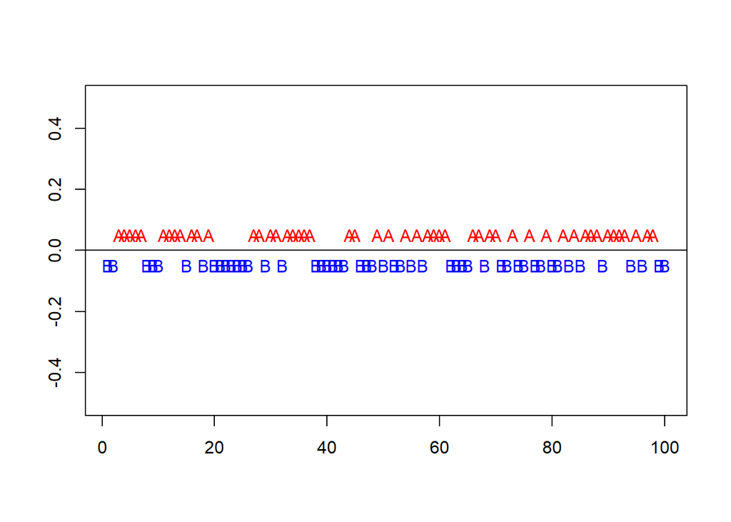

  ```
  ##
  ##  Runs Test - Two sided
  ##
  ## data:  Datosfit2$.std.resid
  ## Standardized Runs Statistic = -0.40204, p-value = 0.6877
  ```

  ```r
  #Prueba de rachas
  library(lawstat)
  lawstat::runs.test(Datosfit2$.std.resid, plot.it = TRUE)
  ```

  ```r
  library(randtests)
  randtests::runs.test(Datosfit2$.std.resid)
  ```

  ```
  ##
  ##  Runs Test
  ##
  ## data:  Datosfit2$.std.resid
  ## statistic = -0.40204, runs = 49, n1 = 50, n2 = 50, n = 100, p-value =
  ## 0.6877
  ## alternative hypothesis: nonrandomness
  ```

  siendo así que no se está rechanzado $H_{0}$, lo cual es justamente lo que buscamos.
- Finalmente la prueba de *Durbin-Watson*

  ```r
  #Prueba para autocorrelación de orden 1 (Durbin-Watson)
  lmtest::dwtest(fit2)
  ```

  ```
  ##
  ##  Durbin-Watson test
  ##
  ## data:  fit2
  ## DW = 2.0289, p-value = 0.5368
  ## alternative hypothesis: true autocorrelation is greater than 0
  ```

  ```r
  library(car)
  # La librería car tiene una función para revisar más órdenes
  durbinWatsonTest(fit2, max.lag=5)
  ```

  ```
  ##  lag Autocorrelation D-W Statistic p-value
  ##    1     -0.02506064      2.028857   0.898
  ##    2     -0.10994695      2.196005   0.274
  ##    3      0.14725154      1.630055   0.112
  ##    4     -0.09643929      2.064546   0.488
  ##    5     -0.01099229      1.887869   0.956
  ##  Alternative hypothesis: rho[lag] != 0
  ```

  no rechazándose $H_{0}$ en todas las pruebas. Concluimos pues que no hay evidencia suficiente en contra del supuesto de la covarianza cero.

## Otro caso

Analicemos este supuesto en el modelo antes de transformar los datos

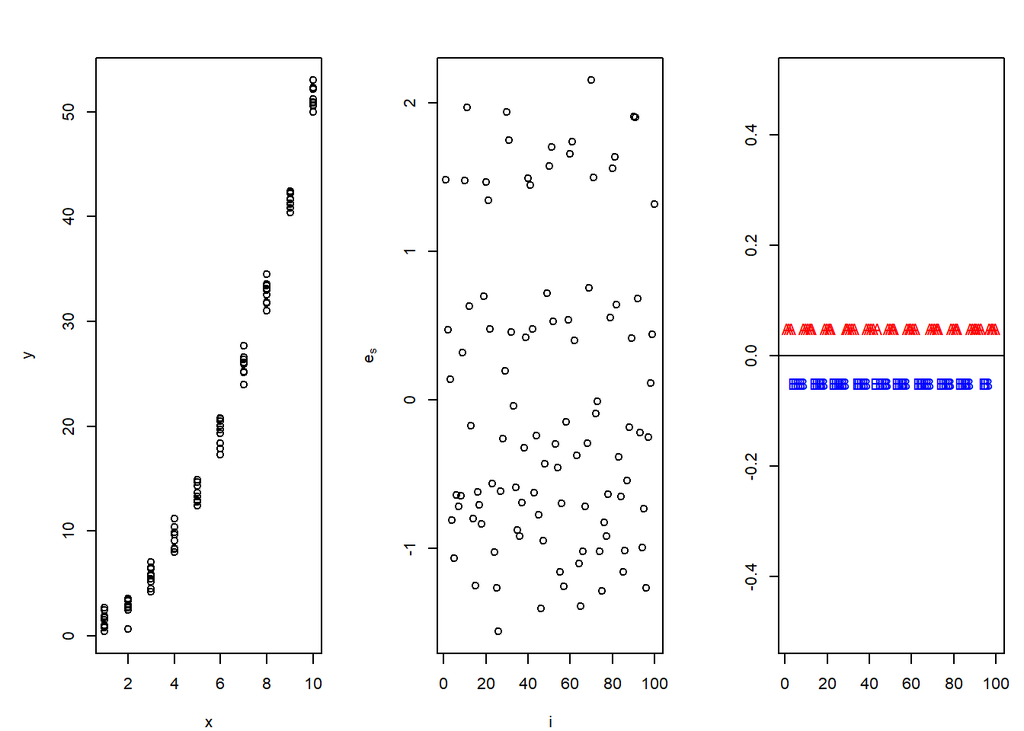

```
##
##  Runs Test - Two sided
##
## data:  Datosfit$.std.resid
## Standardized Runs Statistic = -5.6285, p-value = 1.818e-08
```

```r
# Cálculo de los errores
Datosfit=augment(fit)

# Gráfica original
par(mar=c(4, 5, 3, 1))
par(mfrow=c(1,3))
plot(Datos$x, Datos$y, xlab = TeX("$x$"), ylab=TeX("$y$") )

# Gráfica sobre el índice de los datos
plot(1:length(Datosfit$.std.resid), Datosfit$.std.resid, xlab = TeX("$i$"), ylab=TeX("$e_s$"))

# Prueba de rachas
lawstat::runs.test(Datosfit$.std.resid, plot.it = TRUE)
```

```r
durbinWatsonTest(fit, max.lag=5)
```

```
##  lag Autocorrelation D-W Statistic p-value
##    1       0.6951288     0.5710322   0.000
##    2       0.1907604     1.5756213   0.050
##    3      -0.3047335     2.5662998   0.004
##    4      -0.6735497     3.2966808   0.000
##    5      -0.7799410     3.4816793   0.000
##  Alternative hypothesis: rho[lag] != 0
```

donde en cada prueba se está rechazando $H_{0}$, es decir, es plausible asumir que los errores están autocorrelacionados ($H_{a}$).

Finalmente comparemos las gráficas:

```r
par(mar=c(4, 5, 3, 1))
par(mfrow=c(1,2))

# Datos transformados
lawstat::runs.test(Datosfit2$.std.resid, plot.it = TRUE)
```

```
##
##  Runs Test - Two sided
##
## data:  Datosfit2$.std.resid
## Standardized Runs Statistic = -0.40204, p-value = 0.6877
```

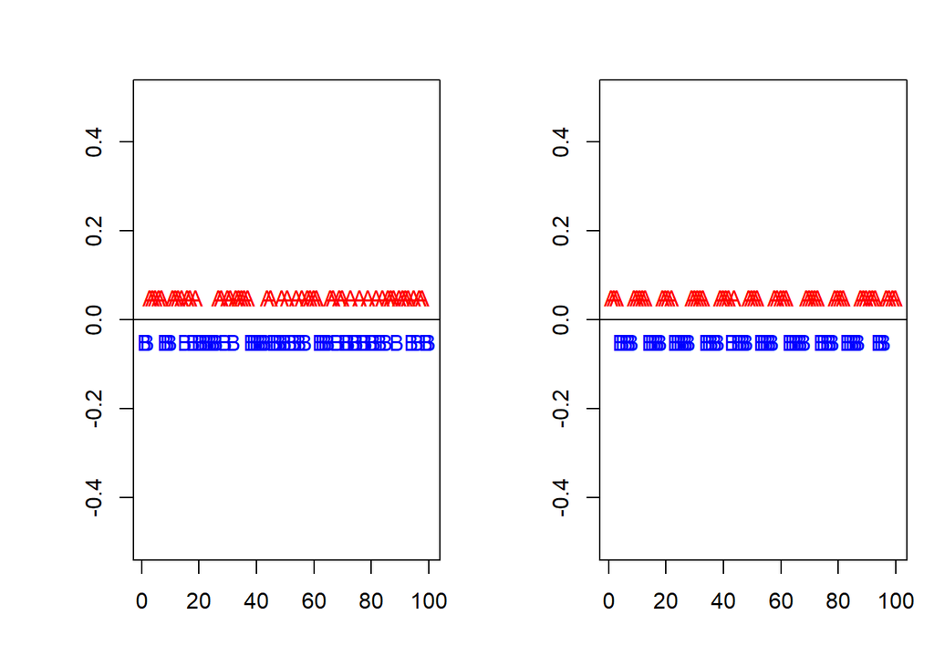

```
##
##  Runs Test - Two sided
##
## data:  Datosfit$.std.resid
## Standardized Runs Statistic = -5.6285, p-value = 1.818e-08
```

```r
# Datos no transformados
lawstat::runs.test(Datosfit$.std.resid, plot.it = TRUE)
```

siendo la gráfica de la derecha en la cual se hace más visible las rachas.